# Heatmap proteome

# Chargement des librairies

```r
library(pheatmap)

library(RColorBrewer)
```

# Import des donnees

selection de 214 proteines

```r
table1<-read.table("C:/Users/Gardette/Documents/APT/2A/Big Data/Proteome/proteome_Ath_selection.csv", sep=";", dec=".", header=T,row.names=1)
```

# Transformation des donnees

```r
table1 <- scale(table1)
```

# Preparation de la heatmap

```r
groupe <- rep(c("Low","Medium","Elevated"),each=3)

sample_group <- data.frame(groupe = groupe)

row.names(sample_group) <- row.names(table1)

my_colour = list(
  groupe = c(
    "Low" = "lightblue",
    "Medium" = "lightgreen",
    "Elevated" = "orange"))
```

# Heatmap

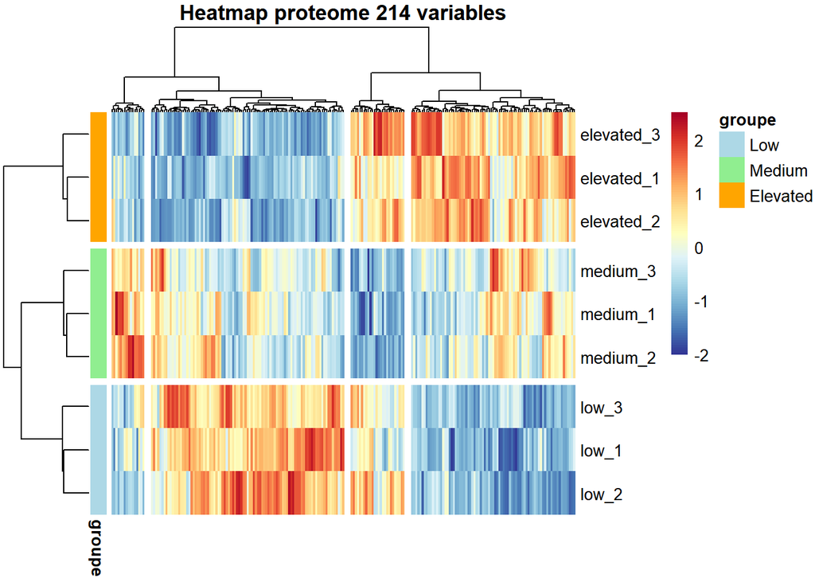

```r
my_heatmap <-
pheatmap(
  as.matrix(table1),
  color = colorRampPalette(rev(brewer.pal(
    n = 11, name = "RdYlBu"
  )))(100),
  clustering_method = "ward.D2",
  annotation_row = sample_group,
  annotation_colors = my_colour,
  cutree_rows = 3,
  cutree_cols = 4,
  show_colnames = F,
  main = "Heatmap proteome 214 variables",
  cex = 1,
  border_color = "black"
)
```

# Analyse de la heatmap : variables

```r
cluster_heatmap <- cutree(my_heatmap$tree_col, k=4)

# codification initiale des clusters

length(cluster_heatmap[cluster_heatmap==1]) # 79 : cluster 4
```

[1] 79

```r
length(cluster_heatmap[cluster_heatmap==2]) # 93 : cluster 2
```

[1] 93

```r
length(cluster_heatmap[cluster_heatmap==3]) # 26 : cluster 3
```

[1] 26

```r
length(cluster_heatmap[cluster_heatmap==4]) # 16 : cluster 1
```

[1] 16

```r
# conversion des n° de clusters pour qu'ils coincident avec les clusters de gauche à droite sur le graphe

x<- cluster_heatmap

y=NULL

for (i in 1:length(x)) {

  val <- x[i]

  if (val==1) {y[i] <- 4}
  else if (val==2){y[i] <- 2}
  else if (val==3){y[i] <- 3}
  else {y[i] <- 1}

}

names(y) <- names(x)


# export de l'appartenance des variables aux clusters

write.table(y,"appartenances_clusters_heatmap_proteome.csv",append=F,sep=";",dec=".",row.names=T,col.names=NA)


# composition des clusters

# cluster 1

length(y[y==1])
```

[1] 16

```r
names(y[y==1])
```

[1] “AT1G70680.1” “AT1G79550.1” “AT2G33070.1” “AT3G14360.1” “AT3G27430.2” “AT4G02280.1” “AT4G11150.1” “AT4G16500.1” “AT5G01670.1” “AT5G42270.1” “AT5G47810.1” “AT5G48100.1” “AT5G50600.1” “AT5G52840.1” “AT5G58290.1” “AT5G61780.1”

```r
# cluster 2

length(y[y==2])
```

[1] 93

```r
names(y[y==2])
```

[1] “AT1G01900.1” “AT1G03890.1” “AT1G07750.1” “AT1G07985.1” “AT1G11910.1” “AT1G14170.1” “AT1G14930.1” “AT1G14940.1” “AT1G14950.1” “AT1G17100.1” “AT1G18270.1” “AT1G19900.1” “AT1G21670.1” “AT1G30360.1” “AT1G47128.1” “AT1G49240.1” “AT1G63770.3” “AT1G64110.1” “AT1G70840.1” “AT1G71695.1” “AT1G77510.1” [22] “AT2G01140.1” “AT2G04780.1” “AT2G05920.1” “AT2G21660.1” “AT2G22420.1” “AT2G22780.1” “AT2G24270.1” “AT2G25970.1” “AT2G28900.1” “AT2G34790.1” “AT2G37220.1” “AT2G37970.1” “AT2G38380.1” “AT2G43750.1” “AT2G43950.1” “AT2G46750.1” “AT3G01280.1” “AT3G02480.1” “AT3G05190.1” “AT3G06050.1” “AT3G08030.1” [43] “AT3G12203.1” “AT3G13300.1” “AT3G14067.1” “AT3G18490.1” “AT3G20390.1” “AT3G20820.1” “AT3G21720.1” “AT3G23490.1” “AT3G29360.1” “AT3G47930.1” “AT3G52850.1” “AT3G54400.1” “AT3G55120.1” “AT3G57020.1” “AT3G60730.1” “AT3G63540.1” “AT4G05420.1” “AT4G16210.1” “AT4G16690.1” “AT4G25130.1” “AT4G27520.1” [64] “AT4G30880.1” “AT4G32920.1” “AT4G34480.1” “AT4G35260.1” “AT4G36360.1” “AT4G39660.1” “AT5G04885.1” “AT5G07030.1” “AT5G09640.1” “AT5G12950.1” “AT5G14780.1” “AT5G15530.1” “AT5G18170.1” “AT5G19140.1” “AT5G20280.1” “AT5G20950.1” “AT5G22460.1” “AT5G26120.1” “AT5G34940.2” “AT5G40370.1” “AT5G46290.1” [85] “AT5G55410.1” “AT5G57110.1” “AT5G57550.1” “AT5G58070.1” “AT5G59310.1” “AT5G63030.1” “AT5G63800.1” “AT5G66590.1” “AT5G66760.1”

```r
# cluster 3

length(y[y==3])
```

[1] 26

```r
names(y[y==3])
```

[1] “AT1G20630.1” “AT1G57720.1” “AT1G68560.1” “AT1G72680.1” “AT1G77120.1” “AT1G78900.1” “AT2G34700.1” “AT3G17940.1” “AT3G26060.1” “AT3G26380.1” “AT3G44100.1” “AT3G44110.1” “AT3G51800.1” “AT3G53110.1” “AT3G62030.1” “AT4G01900.1” “AT4G10750.1” “AT4G12130.1” “AT4G37870.1” “AT5G19860.1” “AT5G26830.1” [22] “AT5G35360.1” “AT5G36880.1” “AT5G50250.1” “AT5G50920.1” “AT5G64570.1”

```r
# cluster 4

length(y[y==4])
```

[1] 79

```r
names(y[y==4])
```

[1] “AT1G01470.1” “AT1G03030.1” “AT1G04480.1” “AT1G07140.1” “AT1G07920.1” “AT1G08110.1” “AT1G09640.1” “AT1G10590.1” “AT1G18500.1” “AT1G19570.1” “AT1G20020.1” “AT1G20200.1” “AT1G20260.1” “AT1G20620.1” “AT1G43670.1” “AT1G47980.1” “AT1G52560.1” “AT1G56600.1” “AT1G65090.2” “AT1G65880.1” “AT1G66430.1” [22] “AT1G68010.1” “AT1G74310.1” “AT1G77090.1” “AT2G19900.1” “AT2G20560.1” “AT2G21820.1” “AT2G22240.1” “AT2G23110.1” “AT2G29300.1” “AT2G30200.1” “AT2G32120.1” “AT2G36640.1” “AT2G37660.1” “AT2G38040.1” “AT2G43520.1” “AT2G44060.1” “AT3G12580.1” “AT3G12780.1” “AT3G12800.1” “AT3G12960.1” “AT3G14310.1” [43] “AT3G14990.1” “AT3G16895.1” “AT3G22200.1” “AT3G23400.1” “AT3G23570.1” “AT3G44300.1” “AT3G51810.1” “AT3G52960.1” “AT3G58450.1” “AT3G58610.1” “AT4G09600.1” “AT4G10020.1” “AT4G16760.1” “AT4G20360.1” “AT4G21020.1” “AT4G21280.1” “AT4G24190.1” “AT4G29840.1” “AT4G35090.1” “AT4G36195.1” “AT4G37000.1” [64] “AT5G03860.1” “AT5G11520.1” “AT5G11880.1” “AT5G20720.1” “AT5G28840.1” “AT5G38170.1” “AT5G43940.1” “AT5G44120.3” “AT5G44310.1” “AT5G50370.1” “AT5G51970.1” “AT5G57655.2” “AT5G66190.1” “AT5G66570.1” “ATCG00120.1” “ATCG00480.1”